# When will I get my money back? The fall of the SP500 in 2022

**by Giancarlo Marchesi**

This notebook studies the current losses of the S&P 500 index during 2022. Although I study data since 1985, the latest fall is only comparable to those in this century. I aim to answer the simple question: When will I get back the money I've lost this year? I study the behavior of the index using monthly prices and caveat for the current inflation and fed funds rate environment.

## What happened to the stock market in the last 12 months?

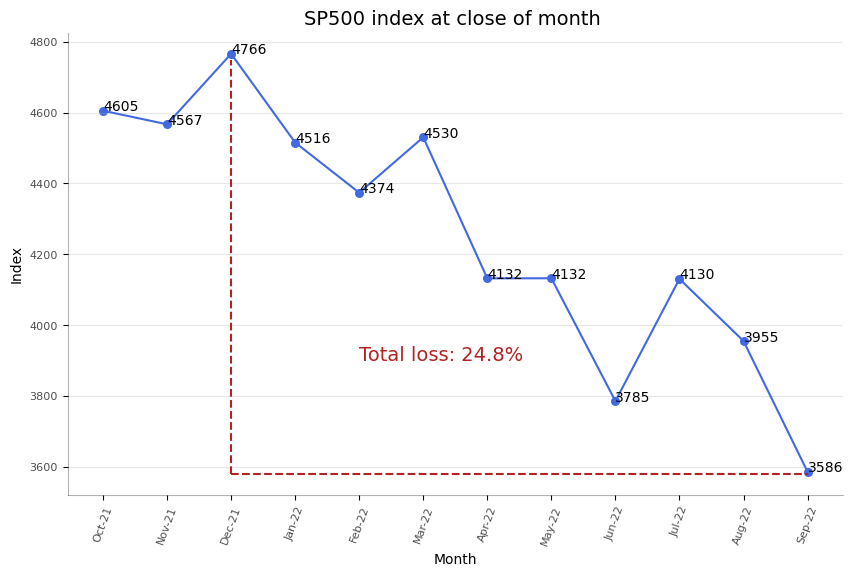

## Some historical context on the losses

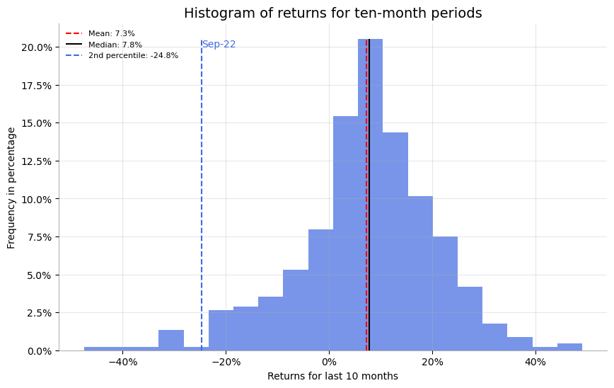

**Extreme fall:**  
The fall of the last ten months ranks in the 2nd percentile of returns, i.e. very unlikely.

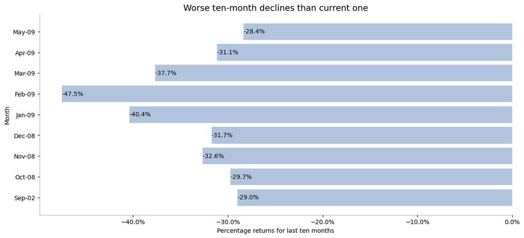

**Bad company:**  
The only two other times we have seen ten-month falls similar to this one were during the lowest point of the dot.com boom, post 9/11, and during the worst months of the great recession.

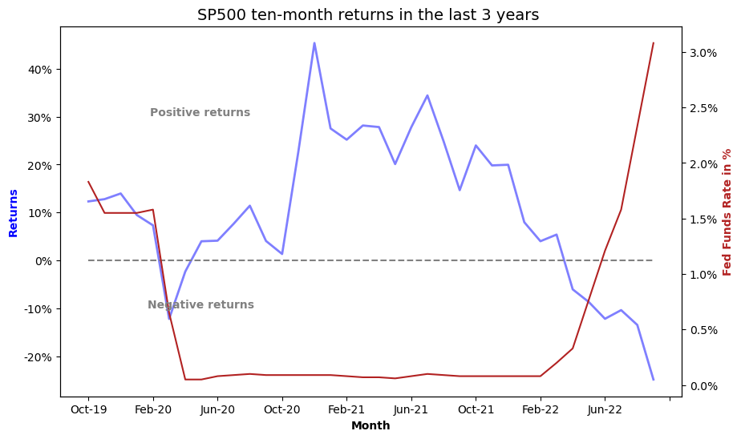

**Pendulum moment:**  
After the intital six months of COVID, returns increased aggresively. As rates have tightened, returns have decreased substantially.